Machine Learning I

# Analysis of customer churn

Jupyter Notebook Documentation

**Unsupervised Learning**

Author Anna Kopecny

Author Adil Zhumagaliyev

Author Alisha Utegenova

Author Assylbek Omarov

**Professor:** prof. Ing. Tomáś Kliegr, Ph.D.

**Seminar:** Monday 18:00 - 19:30

Summer-Semester 2026

```python
#%pip install -r ../requirements.txt

import pandas as pd
import numpy as np
import gower
import matplotlib.pyplot as plt
import matplotlib as mpl
import seaborn as sns

from sklearn.preprocessing import StandardScaler

from kmodes.kprototypes import KPrototypes

import scipy.cluster.hierarchy as sch
from scipy.cluster.hierarchy import fcluster
from sklearn.cluster import AgglomerativeClustering
from scipy.cluster.hierarchy import dendrogram, linkage
from scipy.spatial.distance import squareform

from kneed import KneeLocator
from sklearn.metrics import silhouette_score, silhouette_samples
from matplotlib.cm import get_cmap
from scipy.stats import chi2_contingency

import warnings
```

```python
# Settings
SEED = 42
np.random.seed(SEED)

warnings.filterwarnings("ignore")

my_palette = ["#718096", "#469CDA"]
my_color1 = my_palette[0]
my_color2 = my_palette[1]

cluster_palette = ["#718096", "#469CDA", "#E2725B", "#48BB78", "#D69E2E"]
cat_palette = ["#718096", "#469CDA", "#E2725B", "#48BB78", "#D69E2E", "#9F7AEA", "#ED8936"]

mpl.rcParams.update({
    # Figure
    "figure.figsize": (10, 6),
    "figure.dpi": 300,
    "figure.facecolor": "white",
    "figure.titlesize": 20,
    "figure.titleweight": "bold",

    # Fonts
    "font.size": 13,
    "axes.titlesize": 15,
    "axes.titleweight": "bold",
    "axes.labelsize": 13,
    "legend.fontsize": 11,

    # Grid
    "axes.grid": True,
    "grid.alpha": 0.3,
    "grid.linestyle": "--",

    # Lines
    "lines.linewidth": 2,

    # Cleaner look
    "axes.spines.top": False,
    "axes.spines.right": False
})
```

# 1 Data import and preprocessing

```python
df = pd.read_csv("../data/churn.csv")

df.drop(columns=["customerID"], inplace=True)
df["Churn"] = df["Churn"].map({"Yes": 1, "No": 0})

df["TotalCharges"] = pd.to_numeric(df["TotalCharges"], errors="coerce")
df["TotalCharges"] = df["TotalCharges"].fillna(0)

df.head()
```

|  | gender | SeniorCitizen | Partner | Dependents | tenure | PhoneService | MultipleLines | InternetService | OnlineSecurity | OnlineBackup | DeviceProtection | TechSupport | StreamingTV | StreamingMovies | Contract | PaperlessBilling | PaymentMethod | MonthlyCharges | TotalCharges | Churn |
| --- | --- | --- | --- | --- | --- | --- | --- | --- | --- | --- | --- | --- | --- | --- | --- | --- | --- | --- | --- | --- |
| 0 | Female | 0 | Yes | No | 1 | No | No phone service | DSL | No | Yes | No | No | No | No | Month-to-month | Yes | Electronic check | 29.85 | 29.85 | 0 |
| 1 | Male | 0 | No | No | 34 | Yes | No | DSL | Yes | No | Yes | No | No | No | One year | No | Mailed check | 56.95 | 1889.50 | 0 |
| 2 | Male | 0 | No | No | 2 | Yes | No | DSL | Yes | Yes | No | No | No | No | Month-to-month | Yes | Mailed check | 53.85 | 108.15 | 1 |
| 3 | Male | 0 | No | No | 45 | No | No phone service | DSL | Yes | No | Yes | Yes | No | No | One year | No | Bank transfer (automatic) | 42.30 | 1840.75 | 0 |
| 4 | Female | 0 | No | No | 2 | Yes | No | Fiber optic | No | No | No | No | No | No | Month-to-month | Yes | Electronic check | 70.70 | 151.65 | 1 |

```python
df_cluster = df.drop(columns=["TotalCharges", "Churn"])
```

## 1.1 Preprocessing

## 1.2 Feature Selection and Scaling

```python
num_cols = ['tenure', 'MonthlyCharges']

cat_cols = [
    'Contract',
    'InternetService',
    'PaymentMethod',
    'PaperlessBilling',
    'TechSupport',
    'OnlineSecurity',
    'StreamingTV',
    'DeviceProtection'
]
```

```python
features = num_cols + cat_cols

df_cluster = df[features].copy()

scaler = StandardScaler()
df_cluster[num_cols] = scaler.fit_transform(df_cluster[num_cols])

cat_indices = [df_cluster.columns.get_loc(c) for c in cat_cols]
```

# 2. Clustering

## 2.1 Feature Selection

```python
X = df_cluster.values
```

```python
num_cols
```

```
['tenure', 'MonthlyCharges']
```

```python
cat_cols
```

```
['Contract',
 'InternetService',
 'PaymentMethod',
 'PaperlessBilling',
 'TechSupport',
 'OnlineSecurity',
 'StreamingTV',
 'DeviceProtection']
```

## 2.2 Clustering K-prototypes

**Why K-Prototypes**

- **Mixed-type design:** K-Prototypes extends K-Means for datasets with both numerical and categorical features by combining Euclidean distance (numerical) and simple matching dissimilarity (categorical: 0 if equal, 1 if different).
- **Balanced integration:** The gamma parameter weights the contribution of each distance type, preventing either feature type from dominating the clustering.
- **Interpretable centroids:** Cluster centers use means for numerical features and modes for categorical features, producing directly interpretable profiles (e.g., "tenure = 24, Contract = Month-to-month").
- **Preserves data structure:** No encoding required—the original data structure is maintained without artificial distance distortion.

```python
costs = []
k_range = range(2, 8)

for k in k_range:
    kproto = KPrototypes(n_clusters=k, init="Cao", n_jobs=-1, random_state=SEED)
    kproto.fit(X, categorical=cat_indices)
    costs.append(kproto.cost_)
    print(f"k={k}, cost={kproto.cost_:.2f}")
```

```
k=2, cost=19991.42
k=3, cost=14121.22
k=4, cost=12319.38
k=5, cost=10871.64
k=6, cost=9750.54
k=7, cost=9053.75
```

## 2.3 Chooking the best K

We For K-Prototypes, cost_ (direct analog of inertia in K-Means) is the sum of: (a) squared Euclidean distances between numerical feature values and their cluster centroids, and (b) matching dissimilarities between categorical values and their cluster modes.

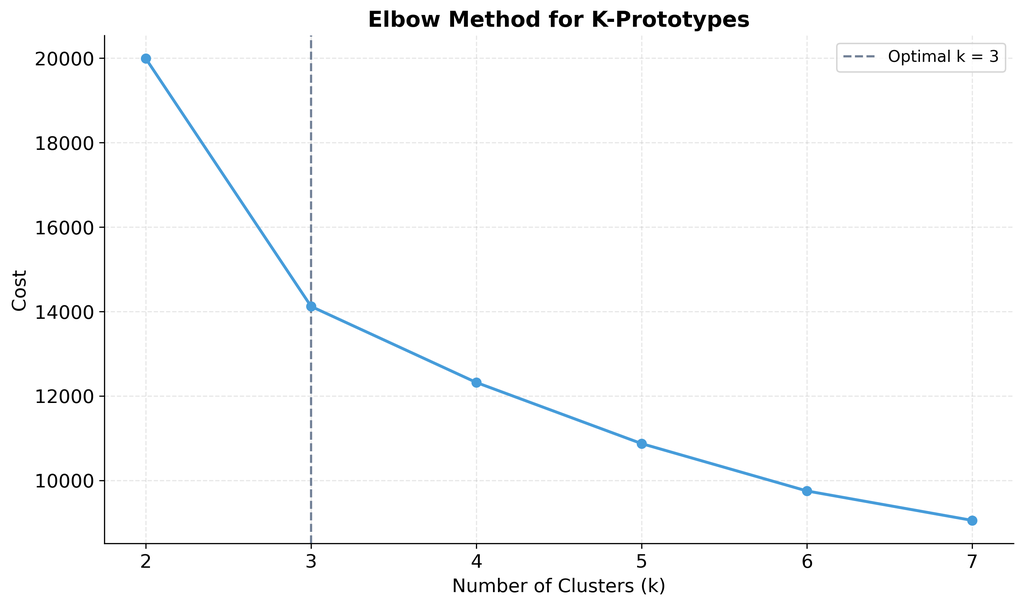

```
Optimal number of clusters: 3
```

```python
knee = KneeLocator(list(k_range), costs, curve="convex", direction="decreasing")
best_k = knee.elbow

# ── PLOT ──
fig, ax = plt.subplots()

ax.plot(list(k_range), costs, marker="o", color=my_color2, zorder=3)
ax.axvline(x=best_k, linestyle="--", color=my_color1, linewidth=1.5,
           label=f"Optimal k = {best_k}")

ax.set_xlabel("Number of Clusters (k)")
ax.set_ylabel("Cost")
ax.set_title("Elbow Method for K-Prototypes")
ax.set_xticks(list(k_range))
ax.legend()

plt.tight_layout()
plt.show()

print(f"\nOptimal number of clusters: {best_k}")
```

At **k = 3**, the cost curve shows a clear bend — moving from k = 2, to k = 3 yields a substantial cost reduction, while k = 4 and beyond produce diminishing returns.

# 3. Fitting the K-Prototypes Model

```python
kproto_final = KPrototypes(n_clusters=best_k, init="Cao", random_state=SEED)
clusters = kproto_final.fit_predict(X, categorical=cat_indices)


df["Cluster"] = clusters
```

```python
print(df.groupby("Cluster")[["tenure", "MonthlyCharges", "TotalCharges"]].mean())

print(df.groupby("Cluster")["Churn"].value_counts(normalize=True))

for col in cat_cols:
    print(f"\n{col}")
    print(df.groupby("Cluster")[col].value_counts(normalize=True))
```

```
            tenure  MonthlyCharges  TotalCharges
Cluster
0        15.128077       70.543175   1102.112481
1        31.011550       22.162128    711.310973
2        58.670626       88.299155   5184.734217
Cluster  Churn
0        0        0.545341
         1        0.454659
1        0        0.925228
         1        0.074772
2        0        0.868890
         1        0.131110
Name: proportion, dtype: float64

Contract
Cluster  Contract
0        Month-to-month    0.888127
         One year          0.099096
         Two year          0.012777
1        Two year          0.408511
         Month-to-month    0.339818
         One year          0.251672
2        Two year          0.448607
         One year          0.338511
         Month-to-month    0.212883
Name: proportion, dtype: float64

InternetService
Cluster  InternetService
0        Fiber optic        0.565285
         DSL                0.434715
1        No                 0.927660
         DSL                0.072340
2        Fiber optic        0.585656
         DSL                0.414344
Name: proportion, dtype: float64

PaymentMethod
Cluster  PaymentMethod
0        Electronic check             0.518853
```

[output cut: 51 more lines]

```
         Yes                    0.007295
2        Yes                    0.719963
         No                     0.280037
Name: proportion, dtype: float64

DeviceProtection
Cluster  DeviceProtection
0        No                     0.744157
         Yes                    0.255843
1        No internet service    0.927660
         No                     0.044985
         Yes                    0.027356
2        Yes                    0.710827
         No                     0.289173
Name: proportion, dtype: float64
```

**Strategic Insights** Cross-Cluster Analysis**

The most striking finding is the **service bundling gap** between clusters with similar monthly spend. Cluster 0 pays $70.54/month but adopts add-on services at extremely low rates (21% OnlineSecurity, 35% StreamingTV, 26% DeviceProtection), while Cluster 2 pays only $18 more ($88.30) yet shows 2-3x higher adoption rates (58% OnlineSecurity, 72% StreamingTV, 71% DeviceProtection). This suggests Cluster 0's high churn (45.5%) isn't driven by price sensitivity but by **low perceived value and shallow product integration**. These customers are paying for internet access but not building ecosystem lock-in through bundled services, making switching costs negligible despite comparable spending to the loyal Cluster 2.

## 3.1 Cluster Profiling and Visualization

```python
cluster_labels = {
    0: "High-Risk Churners",
    1: "Loyal Long-Term",
    2: "Mid-Tier At-Risk"
}
df["Cluster_Name"] = df["Cluster"].map(cluster_labels)
```

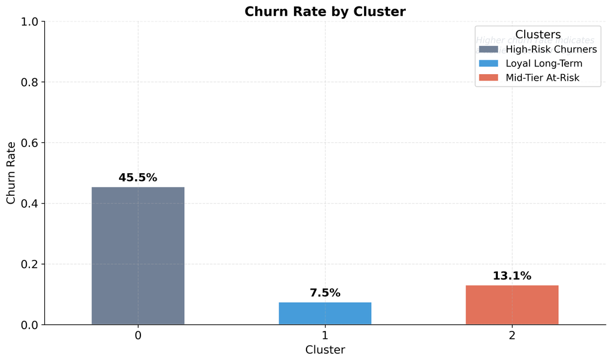

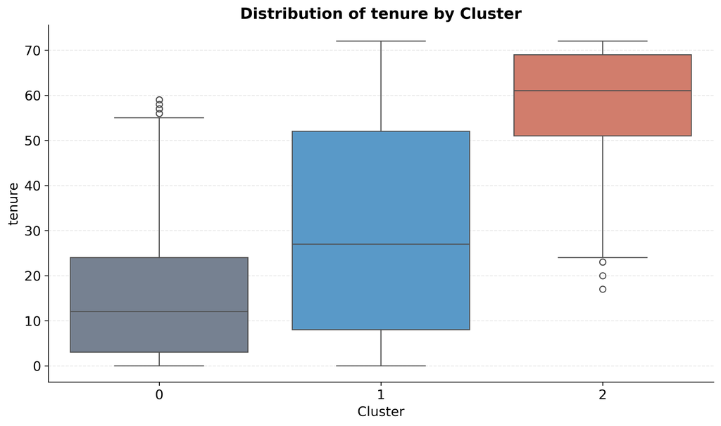

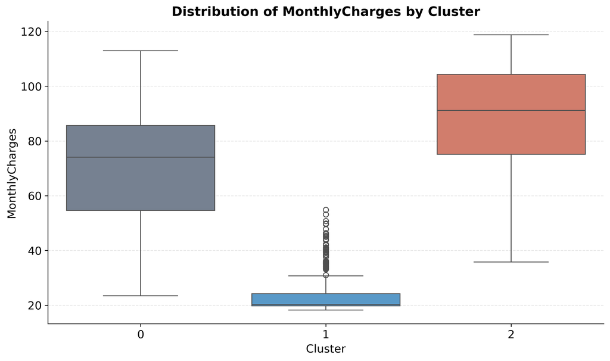

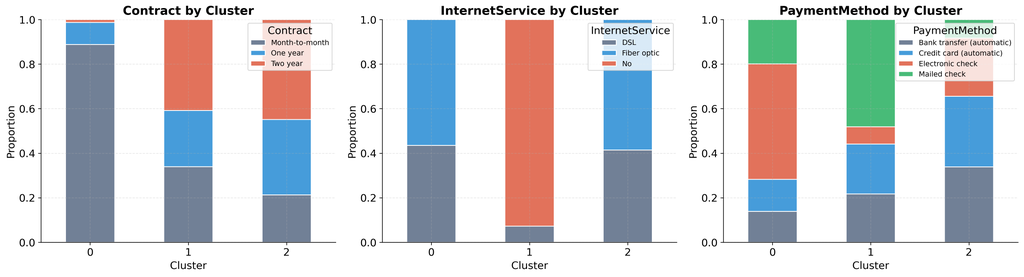

```python
churn_rate = df.groupby("Cluster")["Churn"].mean()

fig, ax = plt.subplots()
bars = churn_rate.plot(
    kind="bar",
    color=cluster_palette[:len(churn_rate)],
    edgecolor="white",
    ax=ax
)

for bar in ax.patches:
    ax.text(
        bar.get_x() + bar.get_width() / 2,
        bar.get_height() + 0.01,
        f"{bar.get_height():.1%}",
        ha="center", va="bottom", fontweight="bold"
    )

ax.set_ylabel("Churn Rate")
ax.set_title("Churn Rate by Cluster")
ax.set_xlabel("Cluster")
ax.set_ylim(0, 1)
plt.xticks(rotation=0)

ax.legend(
    handles=[plt.Rectangle((0, 0), 1, 1, fc=cluster_palette[i]) for i in range(len(churn_rate))],
    labels=[cluster_labels[i] for i in range(len(churn_rate))],
    title="Clusters",
    loc="upper right"
)

ax.annotate(
    "Higher churn rate indicates\na riskier customer segment",
    xy=(0.98, 0.95), xycoords="axes fraction",
    ha="right", va="top",
    fontsize=10, fontstyle="italic", color="#718096"
)

plt.tight_layout()
plt.show()


for col in ["tenure", "MonthlyCharges"]:
    fig, ax = plt.subplots()
    sns.boxplot(
        x="Cluster",
        y=col,
        data=df,
        palette=cluster_palette[:df["Cluster"].nunique()],
        ax=ax
    )
    ax.set_title(f"Distribution of {col} by Cluster")
    ax.set_xlabel("Cluster")
    ax.set_ylabel(col)
    plt.tight_layout()
    plt.show()



cat_features = ["Contract", "InternetService", "PaymentMethod"]
fig, axes = plt.subplots(1, len(cat_features), figsize=(18, 5))

for ax, col in zip(axes, cat_features):
    ct = df.groupby(["Cluster", col]).size().unstack(fill_value=0)
    ct_pct = ct.div(ct.sum(axis=1), axis=0)

    ct_pct.plot(
        kind="bar",
        stacked=True,
        color=cat_palette[:ct_pct.shape[1]],
        edgecolor="white",
        ax=ax
    )
    ax.set_title(f"{col} by Cluster")
    ax.set_xlabel("Cluster")
    ax.set_ylabel("Proportion")
    ax.set_ylim(0, 1)
    ax.tick_params(axis="x", rotation=0)
    ax.legend(title=col, fontsize=9, loc="upper right")

plt.tight_layout()
plt.show()
```

**Churn Rate Summary** K-Prototypes Clustering**

The clustering achieves strong churn stratification with a **6-fold difference** between the highest and lowest risk segments. Cluster 0 loses nearly half its customers (45.5% churn), while Cluster 1 retains over 92% (7.5% churn). Cluster 2 sits in the middle at 13.1%, but is significantly closer to the loyal segment than the high-risk one. This clear separation validates that the clustering successfully identified behaviorally distinct customer groups rather than arbitrary divisions.

From a business perspective, this means **targeted interventions are viable**: resources can be concentrated on the 3,209 customers in Cluster 0 where nearly half will churn without action, while Cluster 1's 1,645 customers require minimal retention investment. Cluster 2 represents a monitoring priority—its 13.1% churn rate suggests some vulnerability, but the segment hasn't crossed into high-risk territory.

## 3.2 Summary table

```python
def cluster_profile(data, cluster_col):
    return data.groupby(cluster_col).agg(
        size=("Churn", "count"),
        churn_rate=("Churn", "mean"),
        avg_tenure=("tenure", "mean"),
        avg_monthly=("MonthlyCharges", "mean"),
        avg_total=("TotalCharges", "mean"),
        pct_month_to_month=("Contract", lambda x: (x == "Month-to-month").mean()),
        pct_fiber=("InternetService", lambda x: (x == "Fiber optic").mean()),
        pct_no_tech_support=("TechSupport", lambda x: (x == "No").mean()),
        pct_no_online_security=("OnlineSecurity", lambda x: (x == "No").mean())
    ).round(2)

print("K-Prototypes Profile")
cluster_profile(df, "Cluster")
```

```
K-Prototypes Profile
```

| Cluster | size | churn_rate | avg_tenure | avg_monthly | avg_total | pct_month_to_month | pct_fiber | pct_no_tech_support | pct_no_online_security |
| --- | --- | --- | --- | --- | --- | --- | --- | --- | --- |
| 0 | 3209 | 0.45 | 15.13 | 70.54 | 1102.11 | 0.89 | 0.57 | 0.79 | 0.79 |
| 1 | 1645 | 0.07 | 31.01 | 22.16 | 711.31 | 0.34 | 0.00 | 0.03 | 0.03 |
| 2 | 2189 | 0.13 | 58.67 | 88.30 | 5184.73 | 0.21 | 0.59 | 0.40 | 0.42 |

```python
churn_comparison = pd.DataFrame()
churn_comparison.index.name = 'Cluster'

churn_comparison['K-Prototypes (Churn)'] = df.groupby('Cluster')['Churn'].mean().round(3)
print(churn_comparison)
```

```
         K-Prototypes (Churn)
Cluster
0                       0.455
1                       0.075
2                       0.131
```

**Results** Cluster Profiling & Interpretation**

- **Cluster 0 — "New & Vulnerable" (3,209 customers, 45% churn):** The largest and highest-risk group. Very new customers (avg tenure ~15 months), overwhelmingly on month-to-month contracts (89%), paying moderate-high charges (~$71). Over half use fiber optic (57%). They churn because they haven't built loyalty yet and have no contractual commitment. The low total charges (~$1,102) confirms they're early-stage customers. This represents an acute early-stage retention problem.
- **Cluster 1 — "Budget Loyal" (1,645 customers, 7% churn):** The most stable group. Low monthly charges (~$22), zero fiber optic, moderate tenure (~31 months), and only 34% on month-to-month (meaning most have committed to contracts). These are basic-service customers—likely DSL or no internet with minimal add-ons. They stay because costs are low and value is clear. Low revenue per customer, but extremely reliable.
- **Cluster 2 — "Loyal High-Value" (2,189 customers, 13% churn):** Long tenure (~59 months), highest monthly charges (~$88), highest total charges (~$5,185), and only 21% on month-to-month—most are on annual contracts. 59% use fiber optic. These are the most valuable customers: they pay premium rates and stay long-term. The 13% churn is manageable but worth monitoring for service quality issues.
- **Action:** The high-churn Cluster 0 needs urgent attention—early engagement programs to convert month-to-month customers to contracts within the first 12-18 months. Cluster 2 should be protected with retention incentives before contract renewal. Cluster 1 is stable but low-margin—consider upsell opportunities for internet upgrades.

# 4. Hierachical Clustering

## 4.1 Feature Selection

```python
features
```

```
['tenure',
 'MonthlyCharges',
 'Contract',
 'InternetService',
 'PaymentMethod',
 'PaperlessBilling',
 'TechSupport',
 'OnlineSecurity',
 'StreamingTV',
 'DeviceProtection']
```

```python
df[features].head()
```

|  | tenure | MonthlyCharges | Contract | InternetService | PaymentMethod | PaperlessBilling | TechSupport | OnlineSecurity | StreamingTV | DeviceProtection |
| --- | --- | --- | --- | --- | --- | --- | --- | --- | --- | --- |
| 0 | 1 | 29.85 | Month-to-month | DSL | Electronic check | Yes | No | No | No | No |
| 1 | 34 | 56.95 | One year | DSL | Mailed check | No | No | Yes | No | Yes |
| 2 | 2 | 53.85 | Month-to-month | DSL | Mailed check | Yes | No | Yes | No | No |
| 3 | 45 | 42.30 | One year | DSL | Bank transfer (automatic) | No | Yes | Yes | No | Yes |
| 4 | 2 | 70.70 | Month-to-month | Fiber optic | Electronic check | Yes | No | No | No | No |

## 4.2 Fitting the Clustering Model

One of the hardest parts of clustering is deciding how many groups you need ($k$). Flat Clustering relies on the Elbow Method, which is a mathematical heuristic that can sometimes be ambiguous. Hierarchical Clustering provides the **Dendrogram** and allows to visually inspect the natural breaks in the data. **Gower Distance** is used instead of Euclidean Distance due to a mixed data types in the dataset. Converting to a squareform to create a (1D) distance vector to be suitable for the model. The dataset does not need scaling or encoding.

```python
df_clust = df[features].copy()

gower_dist = gower.gower_matrix(df_clust)

gower_condensed = squareform(gower_dist, checks=False)
```

```python
linked = sch.linkage(gower_condensed, method='average')
```

## 4.3 Dendogram

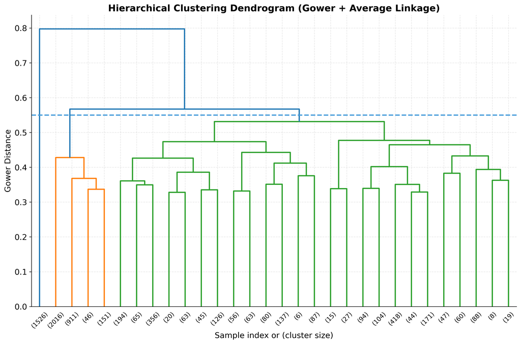

```python
plt.figure(figsize=(12, 8))
sch.dendrogram(linked, truncate_mode='lastp', p=30)
plt.axhline(y=0.55, color=my_color2, linestyle='--',
            label=f'Cut at {0.55} → k={k}')
plt.title('Hierarchical Clustering Dendrogram (Gower + Average Linkage)')
plt.xlabel('Sample index or (cluster size)')
plt.ylabel('Gower Distance')
plt.tight_layout()
plt.show()
```

```
k=2, Silhouette Score=0.4720
k=3, Silhouette Score=0.3808
k=4, Silhouette Score=0.3515
k=5, Silhouette Score=0.3087
k=6, Silhouette Score=0.2999
```

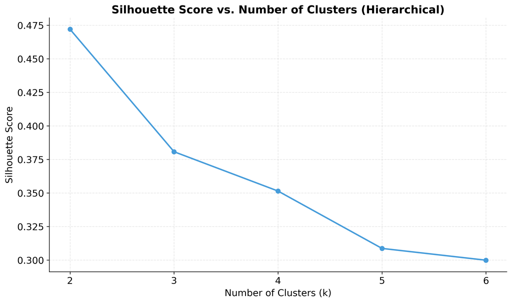

```python
sil_scores = {}

for k in range(2, 7):
    labels = fcluster(linked, t=k, criterion='maxclust')
    score = silhouette_score(gower_dist, labels, metric='precomputed')
    sil_scores[k] = score
    print(f"k={k}, Silhouette Score={score:.4f}")

plt.figure()
plt.plot(list(sil_scores.keys()), list(sil_scores.values()),
         marker='o', color=my_color2)
plt.xlabel("Number of Clusters (k)")
plt.ylabel("Silhouette Score")
plt.title("Silhouette Score vs. Number of Clusters (Hierarchical)")
plt.xticks(range(2, 7))
plt.tight_layout()
plt.show()
```

**Optimal k Selection**

## 4.4 Fitting the Hierarchical Clustering model

```python
# k == 3 based on the dendogram
k = 3

hc = AgglomerativeClustering(
    n_clusters=k,
    metric='precomputed',
    linkage='average'
)
df_cluster['HC_Cluster'] = hc.fit_predict(gower_dist)
```

## 4.5 Hierarchical Profile

```python
hc_remap = {0: 2, 1: 1, 2: 0}
df['HC_Cluster'] = df_cluster['HC_Cluster'].map(hc_remap)

churn_comparison['Hierarchical'] = df.groupby('HC_Cluster')['Churn'].mean().round(3)
churn_comparison
```

| Cluster | K-Prototypes (Churn) | Hierarchical |
| --- | --- | --- |
| 0 | 0.455 | 0.476 |
| 1 | 0.075 | 0.074 |
| 2 | 0.131 | 0.112 |

```python
print("Hierarchical Profile")
cluster_profile(df, "HC_Cluster")
```

```
Hierarchical Profile
```

| HC_Cluster | size | churn_rate | avg_tenure | avg_monthly | avg_total | pct_month_to_month | pct_fiber | pct_no_tech_support | pct_no_online_security |
| --- | --- | --- | --- | --- | --- | --- | --- | --- | --- |
| 0 | 3124 | 0.48 | 18.71 | 72.92 | 1479.81 | 0.99 | 0.65 | 0.82 | 0.83 |
| 1 | 1526 | 0.07 | 30.55 | 21.08 | 662.60 | 0.34 | 0.00 | 0.00 | 0.00 |
| 2 | 2393 | 0.11 | 51.37 | 81.96 | 4355.24 | 0.11 | 0.45 | 0.37 | 0.38 |

**Hierarchical Clustering Results** Gower Distance Method**

# 5. Validation

## 5.1 Silhouette Score

```python
sil_kproto = silhouette_score(gower_dist, df['Cluster'], metric='precomputed')
print(f"K-Prototypes Silhouette Score: {sil_kproto:.3f}")

sil_hc = silhouette_score(gower_dist, df['HC_Cluster'], metric='precomputed')
print(f"Hierarchical Silhouette Score:  {sil_hc:.3f}")
```

```
K-Prototypes Silhouette Score: 0.347
Hierarchical Silhouette Score:  0.381
```

## 5.2 Silhouette Plots per Cluster

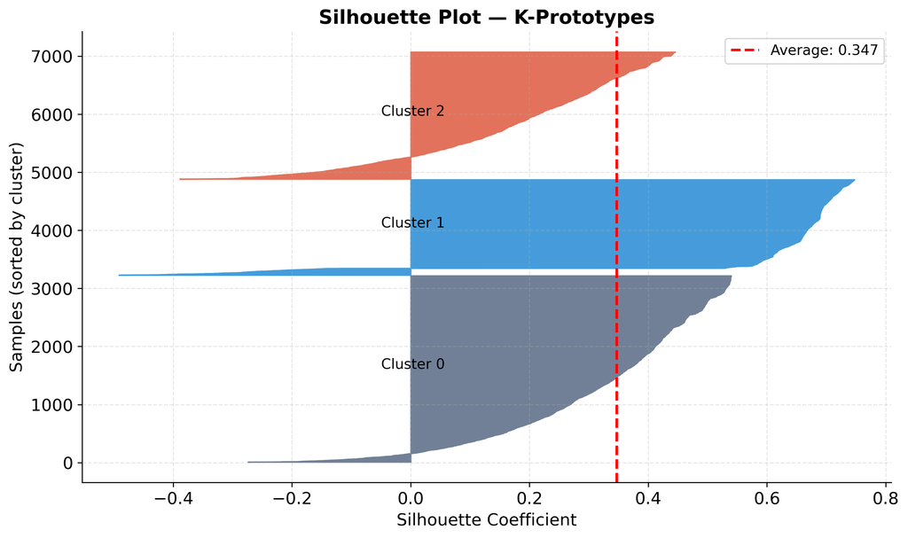

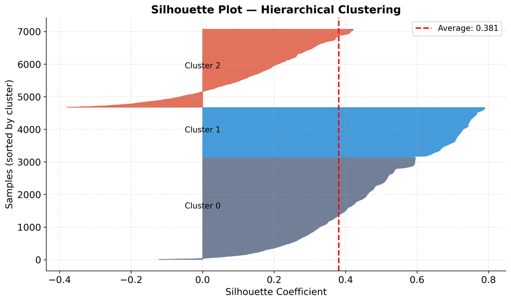

```python
def plot_silhouette(dist_matrix, labels, title):
    sil_vals = silhouette_samples(dist_matrix, labels, metric='precomputed')
    n_clusters = len(set(labels))

    fig, ax = plt.subplots(figsize=(10, 6))
    y_lower = 10

    for i in range(n_clusters):
        cluster_sil = np.sort(sil_vals[labels == i])
        size_i = len(cluster_sil)
        y_upper = y_lower + size_i

        ax.fill_betweenx(np.arange(y_lower, y_upper), 0, cluster_sil,
                         color=cluster_palette[i])
        ax.text(-0.05, y_lower + 0.5 * size_i, f"Cluster {i}", fontsize=11)
        y_lower = y_upper + 10

    avg = np.mean(sil_vals)
    ax.axvline(x=avg, color="red", linestyle="--",
               label=f"Average: {avg:.3f}")
    ax.set_xlabel("Silhouette Coefficient")
    ax.set_ylabel("Samples (sorted by cluster)")
    ax.set_title(title)
    ax.legend()
    plt.tight_layout()
    plt.show()

plot_silhouette(gower_dist, df['Cluster'].values,
                "Silhouette Plot — K-Prototypes")
plot_silhouette(gower_dist, df['HC_Cluster'].values,
                "Silhouette Plot — Hierarchical Clustering")
```

**Silhouette Analysis** Cluster Quality & Separation**

Both clustering methods achieve silhouette scores in the 0.35–0.38 range, which falls within the 'weak-to-moderate structure' band. However, this is typical for customer segmentation on real-world data where segments naturally overlap.

In both methods, the loyal customer segment (Cluster 1) is consistently the most distinctly separated, while the high-risk and mid-tier segments share more ambiguous boundaries. This is expected—at-risk customers often transition gradually from stable to churning, rather than forming a sharply distinct group. The Hierarchical model with Gower distance slightly outperforms K-Prototypes in overall cluster separation (0.381 vs. 0.347).

## 5.3 Results of Hierchical vs Flat clustering

```python
churn_comparison
```

| Cluster | K-Prototypes (Churn) | Hierarchical |
| --- | --- | --- |
| 0 | 0.455 | 0.476 |
| 1 | 0.075 | 0.074 |
| 2 | 0.131 | 0.112 |

```python
mapping = pd.crosstab(df['Cluster'], df['HC_Cluster'])
mapping
```

| HC_Cluster Cluster | 0 | 1 | 2 |
| --- | --- | --- | --- |
| 0 | 2713 | 0 | 496 |
| 1 | 36 | 1526 | 83 |
| 2 | 375 | 0 | 1814 |

**Cross-Method Validation** Clustering Convergence**

Both methods consistently identify three distinct customer segments: a high-risk group (Cluster 0) with churn rates above 45%, a loyal group (Cluster 1) with churn below 8%, and a mid-tier group (Cluster 2) with moderate churn around 11–13%. The close agreement between the two methods confirms that this segmentation reflects genuine structure in the data rather than an artifact of any single algorithm.

**Model Validation** K-Prototypes vs Hierachical Clustering**

The convergence here is strong. Two fundamentally different algorithms—K-Prototypes (partitional, using Euclidean + matching dissimilarity) and Hierarchical (agglomerative, using Gower distance)—independently discovered the same customer structure. This suggests that these three segments are real patterns in the data, not artifacts of one particular method.

The small differences are actually informative too. The high-risk segment is slightly smaller in HC (3,124 vs 3,209) but has a slightly higher churn rate (47.6% vs 45.5%). This suggests HC drew a tighter boundary around the riskiest customers, pulling a few borderline cases into the mid-tier group—which is why the mid-tier segment grew slightly (2,393 vs 2,189) and its churn rate dropped slightly (11.2% vs 13.1%). The loyal segment is remarkably stable across both methods, meaning those customers are clearly distinct from the rest.